## R Markdown

First, we are going to load in the data and look at summary measures of COVID-19 sex-disaggregated case and death data. The data begins April 13th 2020 and ends November 30th 2020. For are going to treat this whole time as one period, so we’d like to group by state and collapse all dates for both cases and deaths.

```
##    Min. 1st Qu.  Median    Mean 3rd Qu.    Max.
##  0.7624  0.8758  0.9233  0.9405  0.9566  1.8252
```

```
##    Min. 1st Qu.  Median    Mean 3rd Qu.    Max.
##  0.8938  1.0425  1.1311  1.1743  1.3054  1.8875
```

Looking at the COVID death sex ratio, it presents a different story. We see the distribution of death sex ratios lean towards values above 1. The minimum sex ratio is higher than that of cases, and has a value of 0.8938. The median is 1.1311 and the mean is 1.1743, which is less symmetrically distributed than the case data and might be slightly skewed to the right. This crude measure may imply that men die from COVID-19 at a higher rate than women

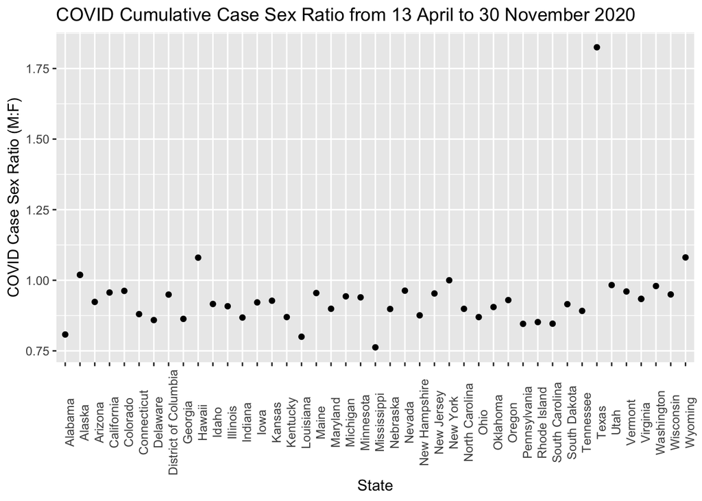

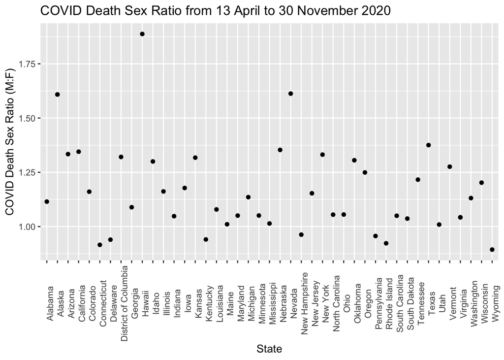

By looking at the simple plots above, for the cumulative COVID case sex ratio we see most of the data points converging below 1. Texas is clearly an outlier with a very high sex ratio, whereas Mississippi and Alabama are also outliers but with a very low sex ratio. The lower the sex ratio, more women represent cases than men. The higher the sex ratio, more men represent cases than women.

Now, going to merge state sex ratios to compare them to cumulative COVID sex ratios by state.

```
##    Min. 1st Qu.  Median    Mean 3rd Qu.    Max.
##  0.8989  0.9385  0.9578  0.9602  0.9780  1.0351
```

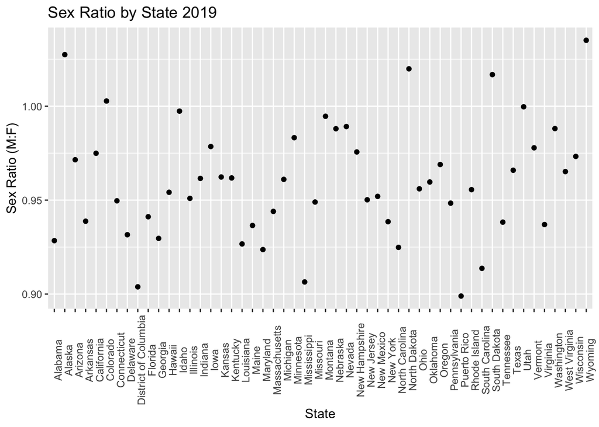

Not every state has equal time points which will affect our graphs, unfortunately. This is a limitation of this exploratory analysis.

```
##
##  1-sample proportions test without continuity correction
##
## data:  5556928 out of 11411993, null probability 0.5
## X-squared = 7788.8, df = 1, p-value < 2.2e-16
## alternative hypothesis: true p is not equal to 0.5
## 95 percent confidence interval:
##  0.4866476 0.4872276
## sample estimates:
##         p
## 0.4869376
```

```
##
##  1-sample proportions test without continuity correction
##
## data:  118070 out of 219628, null probability 0.5
## X-squared = 1241.4, df = 1, p-value < 2.2e-16
## alternative hypothesis: true p is not equal to 0.5
## 95 percent confidence interval:
##  0.5355050 0.5396753
## sample estimates:
##         p
## 0.5375908
```

We take the cumulative male cases and deaths and the total cumulative cases and deaths to perform a one sample Z-test. For this calculation, I collapsed states and found a summary cumulative case and death count for November 30ths (the last day in our dataset) for the time period we are looking at. In the case of the one sample Z-test for cases, we would expect that males would constitue roughly half total cases (0.5) so that is our null hypothesis.

Both tests were statistically significant. In testing whether the proportion of men with COVID out of total COVID cases deviates from the null, our results suggest that the ratio of COVID cases between men and women is not 1:1. More specifically, that males do not consitute half of total cases or half of total deaths. These results were statistically significant ( p-value < 0.001). We found similar results when testing the proportion of deaths among males compared to the total. These results were also statistically significant ( p-value < 0.001). We will need to investigate a little more to see why this ratio is not 1:1 as we would expect.

```
##    Min. 1st Qu.  Median    Mean 3rd Qu.    Max.
##   19.63   86.51   91.81   93.87   96.31  370.57
```

```
##    Min. 1st Qu.  Median    Mean 3rd Qu.    Max.
##  0.3333  0.9682  1.0887  1.1515  1.2696  6.0000
```

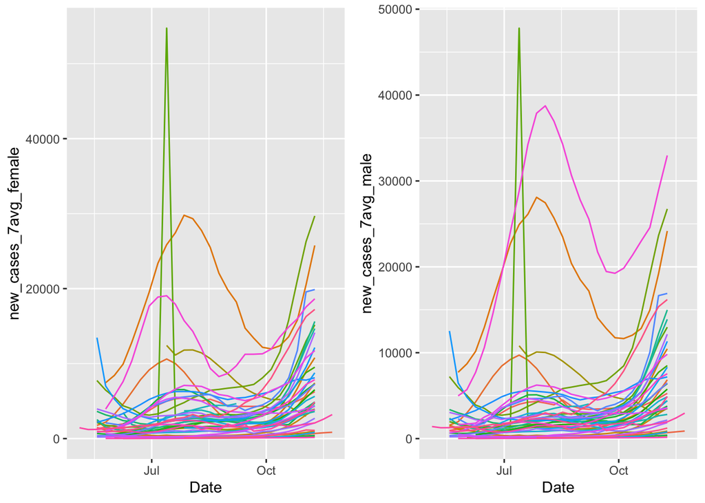

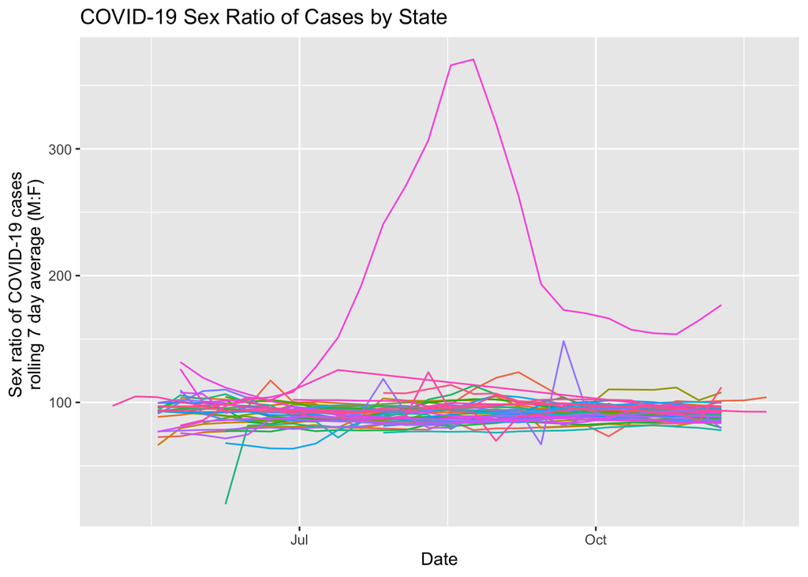

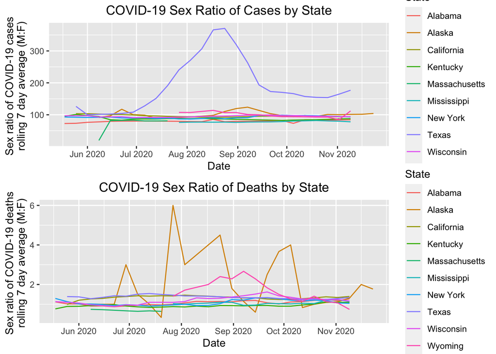

From these basic graphs, this leads us to think that the COVID case and death sex ratios do vary by state–but not for all states. We chose 10 states to focus on in these graphs, but from the graphs prior it looks like the trend is similar for all states.

```
##
## Call:
## lm(formula = new_cases_7avg_sex ~ sex_ratio + X2019.Uninsured +
##     medicaid + Percent.Pov, data = us_covid_june_cutoff)
##
## Residuals:
##     Min      1Q  Median      3Q     Max
## -63.210  -4.877  -0.068   5.656  19.091
##
## Coefficients:
##                 Estimate Std. Error t value Pr(>|t|)
## (Intercept)       8.3352    36.8468   0.226   0.8214
## sex_ratio        81.2885    37.5716   2.164   0.0324 *
## X2019.Uninsured   1.2855     0.4419   2.909   0.0043 **
## medicaidYes      -2.0369     2.6012  -0.783   0.4351
## Percent.Pov      -0.4052     0.4554  -0.890   0.3754
## ---
## Signif. codes:  0 '***' 0.001 '**' 0.01 '*' 0.05 '.' 0.1 ' ' 1
##
## Residual standard error: 10.25 on 123 degrees of freedom
##   (4 observations deleted due to missingness)
## Multiple R-squared:  0.2115, Adjusted R-squared:  0.1859
## F-statistic:  8.25 on 4 and 123 DF,  p-value: 6.283e-06
```

```
##
## Call:
## lm(formula = new_deaths_7avg_sex ~ sex_ratio + X2019.Uninsured +
##     medicaid + Percent.Pov, data = us_covid_june_cutoff)
##
## Residuals:
##      Min       1Q   Median       3Q      Max
## -0.62409 -0.14473  0.01066  0.10063  1.76110
##
## Coefficients:
##                  Estimate Std. Error t value Pr(>|t|)
## (Intercept)      0.508991   0.969227   0.525   0.6004
## sex_ratio        0.178000   0.988294   0.180   0.8574
## X2019.Uninsured  0.046744   0.011623   4.022   0.0001 ***
## medicaidYes      0.086972   0.068422   1.271   0.2061
## Percent.Pov     -0.008748   0.011979  -0.730   0.4666
## ---
## Signif. codes:  0 '***' 0.001 '**' 0.01 '*' 0.05 '.' 0.1 ' ' 1
##
## Residual standard error: 0.2697 on 123 degrees of freedom
##   (4 observations deleted due to missingness)
## Multiple R-squared:  0.167,  Adjusted R-squared:  0.1399
## F-statistic: 6.163 on 4 and 123 DF,  p-value: 0.0001488
```

```
##
## Call:
## lm(formula = case_ratio_cum ~ sex_ratio + X2019.Uninsured + medicaid +
##     Percent.Pov, data = us_nov)
##
## Residuals:
##      Min       1Q   Median       3Q      Max
## -0.16790 -0.06357 -0.02681  0.02915  0.59156
##
## Coefficients:
##                 Estimate Std. Error t value Pr(>|t|)
## (Intercept)      1.10380    0.83084   1.329  0.19236
## sex_ratio       -0.24934    0.83054  -0.300  0.76574
## X2019.Uninsured  0.03213    0.01025   3.136  0.00341 **
## medicaidYes      0.04538    0.05604   0.810  0.42335
## Percent.Pov     -0.01905    0.01040  -1.833  0.07509 .
## ---
## Signif. codes:  0 '***' 0.001 '**' 0.01 '*' 0.05 '.' 0.1 ' ' 1
##
## Residual standard error: 0.1335 on 36 degrees of freedom
##   (1 observation deleted due to missingness)
## Multiple R-squared:  0.2706, Adjusted R-squared:  0.1896
## F-statistic: 3.339 on 4 and 36 DF,  p-value: 0.02005
```

```
##
## Call:
## lm(formula = death_ratio_cum ~ sex_ratio + X2019.Uninsured +
##     medicaid + Percent.Pov, data = us_nov)
##
## Residuals:
##      Min       1Q   Median       3Q      Max
## -0.29736 -0.13932 -0.00066  0.11034  0.69218
##
## Coefficients:
##                 Estimate Std. Error t value Pr(>|t|)
## (Intercept)     -1.64789    1.23042  -1.339   0.1889
## sex_ratio        2.63679    1.22998   2.144   0.0389 *
## X2019.Uninsured  0.01116    0.01517   0.735   0.4670
## medicaidYes      0.05231    0.08299   0.630   0.5324
## Percent.Pov      0.01368    0.01539   0.889   0.3800
## ---
## Signif. codes:  0 '***' 0.001 '**' 0.01 '*' 0.05 '.' 0.1 ' ' 1
##
## Residual standard error: 0.1976 on 36 degrees of freedom
##   (1 observation deleted due to missingness)
## Multiple R-squared:  0.185,  Adjusted R-squared:  0.09445
## F-statistic: 2.043 on 4 and 36 DF,  p-value: 0.109
```

For our cross-sectional analysis, we looked at only dates in June 2020. Our main outcome was the COVID case sex ratio and COVID death sex ratio (M:F). These were calculated using the 7 rolling day average of new cases. Our main exposure variable was sex ratio for each state. The rolling 7 day average. We adjusted for socioeconomic covariates and were going to include median income, but this was perfectly collinear with poverty and other covariates so it was ommitted in the final analysis.

This suggests that other factors besides the sex ratio in the state are contributing to the differences in COVID deaths between men and women.

*Using cumulative cases as the outcome*

We additionally used cumulative COVID case and death sex ratio as the outcome.

For the association between sex ratio and cumulative COVID case sex ratio on November 9th, the association between sex ratio and COVID case sex ratio was negative, however, was not statistically sigifnicant (p-value = 0.76574) after adusting for state-level SES covariates.

For COVID death sex ratio, a increment in sex ratio of 1 in a state predicts a 2.64 increment in COVID death sex ratio holding all else constant (p = 0.0389). This was statistically siginificant at the 0.05 alpha level.

In hypothesizing the difference in results between daily new COVID cases and deaths and the cumulative measure, future analyses should do a sensitivity analysis using different months .

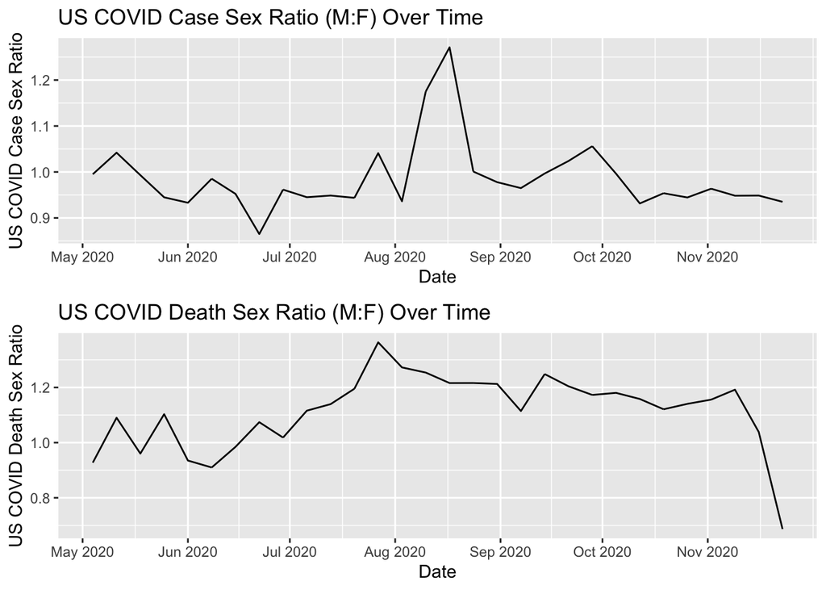

It looks like between August and September 2020, there was a large spike in the COVID case sex ratio where men were disproportionately getting COVID cases than women for the US. Conversely, between June and July 2020 it looks like women were disproportionately representing COVID cases in the US compared to men. However, on average over time, this ratio hovered around 1 although it does appear to have fluctuated over time.

The curve for the US COVID death sex ratio looks much different. It’s above 1 most of the time, with it’s highest peak in August 2020. This suggests that men are dispproportionately representing COVID deaths than women. The ratio quickly drops after November 2020 but this is most likely due to an issue with the data or reporting.

The curves are not symmetrical to each other, and so while more women were getting COVID cases in the months leading up to August (represented by a COVID case sex ratio below 1), it appears that more men were dying from COVID especially after July 2020. From our regression model, this discrepancy is not fully explained by the state sex ratio or by SES factors.

```
##
## Call:
## lm(formula = new_cases_7avg_sex ~ sex_ratio + X2019.Uninsured +
##     medicaid + Percent.Pov + as.factor(month), data = us_covid_complete)
##
## Residuals:
##     Min      1Q  Median      3Q     Max
## -54.056  -8.968  -1.604   5.340 238.971
##
## Coefficients:
##                    Estimate Std. Error t value Pr(>|t|)
## (Intercept)         85.5484    25.4064   3.367 0.000791 ***
## sex_ratio           -6.7665    25.4618  -0.266 0.790489
## X2019.Uninsured      4.3882     0.3160  13.885  < 2e-16 ***
## medicaidYes          7.4409     1.7425   4.270 2.16e-05 ***
## Percent.Pov         -2.1878     0.3257  -6.716 3.25e-11 ***
## as.factor(month)6   -4.2028     3.4997  -1.201 0.230096
## as.factor(month)7   -4.0788     3.5261  -1.157 0.247674
## as.factor(month)8    1.1573     3.4350   0.337 0.736262
## as.factor(month)9   -0.8019     3.4899  -0.230 0.818314
## as.factor(month)10  -2.1791     3.4866  -0.625 0.532139
## as.factor(month)11  -2.4561     3.7675  -0.652 0.514617
## ---
## Signif. codes:  0 '***' 0.001 '**' 0.01 '*' 0.05 '.' 0.1 ' ' 1
##
## Residual standard error: 19.69 on 925 degrees of freedom
##   (26 observations deleted due to missingness)
## Multiple R-squared:  0.2226, Adjusted R-squared:  0.2142
## F-statistic: 26.49 on 10 and 925 DF,  p-value: < 2.2e-16
```

```
##
## Call:
## lm(formula = new_deaths_7avg_sex ~ sex_ratio + X2019.Uninsured +
##     medicaid + Percent.Pov + as.factor(month), data = us_covid_complete)
##
## Residuals:
##     Min      1Q  Median      3Q     Max
## -1.2488 -0.1552 -0.0333  0.1135  4.4178
##
## Coefficients:
##                     Estimate Std. Error t value Pr(>|t|)
## (Intercept)        -2.943126   0.445364  -6.608 6.55e-11 ***
## sex_ratio           3.650307   0.446336   8.178 9.44e-16 ***
## X2019.Uninsured     0.037472   0.005540   6.764 2.38e-11 ***
## medicaidYes         0.094797   0.030546   3.103  0.00197 **
## Percent.Pov         0.008267   0.005710   1.448  0.14801
## as.factor(month)6  -0.024654   0.061348  -0.402  0.68787
## as.factor(month)7   0.118663   0.061812   1.920  0.05520 .
## as.factor(month)8   0.193824   0.060214   3.219  0.00133 **
## as.factor(month)9   0.150118   0.061176   2.454  0.01432 *
## as.factor(month)10  0.125035   0.061119   2.046  0.04106 *
## as.factor(month)11  0.130388   0.066044   1.974  0.04865 *
## ---
## Signif. codes:  0 '***' 0.001 '**' 0.01 '*' 0.05 '.' 0.1 ' ' 1
##
## Residual standard error: 0.3451 on 925 degrees of freedom
##   (26 observations deleted due to missingness)
## Multiple R-squared:  0.2052, Adjusted R-squared:  0.1966
## F-statistic: 23.88 on 10 and 925 DF,  p-value: < 2.2e-16
```

*Final Thoughts, Takeways, and Limitations of this Exploratory Analysis*

We began this exploratory analysis looking at crude differences between states in terms of daily new COVID-19 case and death sex ratios, cumulative COVID sex ratios, and sex ratios by state. From these visualizations, it appeared that there were differences across states in all three indicators. From our crude summary measures, the daily COVID case sex ratio tended to be slightly lower than women suggesting that more women than men were counted as COVID cases. The daily COVID death sex ratio tended to be above 1 suggesting that more men than women were represented in COVID deaths.

Looking at daily COVID case and death sex ratios by state, it is evident that there are differences between states. What explains these differences? We first performed a one sample z test to test the hypothesis of whether cumulative male cases and deaths is equal to 0.5 of the total cases. We rejected the null, suggesting that cumulative male cases and deaths did not comprise 50% of cumulative total cases . Then, using a cutoff date of June 2020 for a cross-sectional analysis, we regressed daily COVID case and death sex ratio with state-level covariates with state sex ratio as our main predictor variable. While some results were statistically significant and may explain some state-level differences in COVID sex ratios, some coefficients were also unstable probably due to the quality of the data. Future analyses should perform sensitivity analyses with different cutoff months since we only looked at June given that it was the month with the most complete data and time points for each state.

When using cumulative COVID sex ratios as our main outcome, results were more stable as in the magnitude of the coeffcients were not uncharasterically large, however, only the association between state sex ratio and cumulative COVID death sex ratio was statistically significant. While some state-level SES were statistically siginificant and might have explained some of the state level differences in COVID sex ratio, some of the inconsistencies in the data like 9,000 cases for one day and then 0 the next make us hesitant regarding the reliability of these results.

To look at US trends over time, we plotted cumlative US total case and death *sex ratios* over time. We saw that, in fact, the trend was not the same over time and the two trends–interestingly enough– did not mirror each other. It appeared that the US COVID sex ratio trended below 1 meaning that women comprised more COVID cases than men. The COVID death sex ratio, on the other hand, trended above 1. Another thing to point out, is that the trends did not seem to coincide. Spikes in female COVID cases, for example, did not seem to lead to spikes in female COVID deaths but the opposite.

*Limitations*

Overall, this analysis was an initial exploration of the data. There are many limitations such as the missingness of the data and inconsistencies. A potential explanation for the quality of the data may be that sex-disaggregated COVID data was less complete or recorded inconsistently.

Future analyses should try the regression with multiple cutoff points as well as include additional covariates that may explain state-level differences in COVID sex ratios. Additional visualizations would also help with understanding of the data. For example, a visulization of the different time points of the data may have helped understand its limitations.

Another limitation was my technical knowlege of longitudinal analyses. If I were to proceed with this analysis, I would definitely spend more time studying longtiduinal models to increase my understanding of the interpretation of these models.

*Concluding Remarks*

The intention of this study was to make the case for sex-disaggregated COVID-19 data. We explored sex differences in COVID-19 cases and deaths across states and tested to see if some of this variation was explained by state-level sex and SES covariates. We did find that there were crude differences in the COVID case and death burdens between sexes and across states. However, we did not conclusively explain these differences between states. Overall, this exploratory analysis does make a case for sex-disaggregated data in that the preliminary results suggested differences between sexes and differences in the COVID sex ratio across states. The incomplete nature of this data is another motivating factor to improve sex-disaggregated data COVID data collection.